# Steelhead Adult Habitat Scaling

sadie

December 18, 2018

This document develops a method for scaling the available adult steelhead wua data to the other watersheds

## Adult Trout and Steelhead WUAs

There is habitat modeling for adult trout or steelhead on 5 watersheds:

**Adult Trout**

1. Battle Creek
2. Butte Creek

**Steelhead**

3. Merced River
4. Tuolumne River
5. Yuba River

## Modeled WUA Exploration

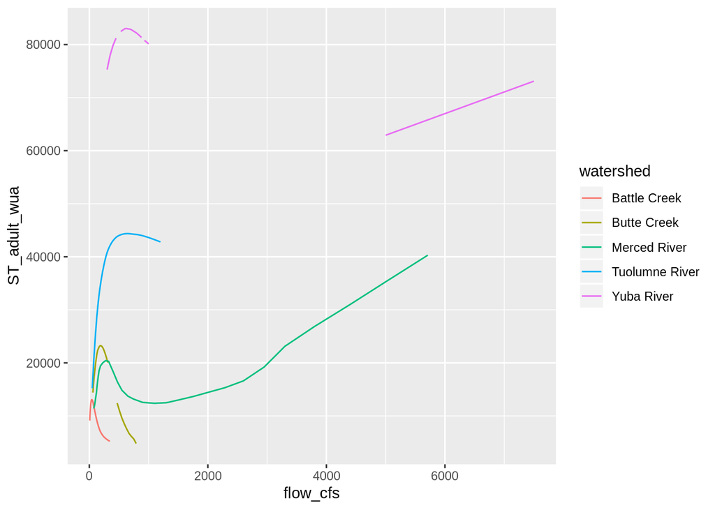

Yuba and Tuolumne WUA values are much higher than the other watersheds, they appear to be proporitonately higher based on watershed size.

Below are the mean values of flow in the monthes December through May. Tuolumne is about twice that of Merced and Yuba is about four times Merced. This is similar to the differences between these watershed’s WUA curves.

[output not shown]

In the following plot, the black line represents the ratio of Yuba/Merced mean flows and the red line represents the ration of Tuolumne/Merced mean flows.

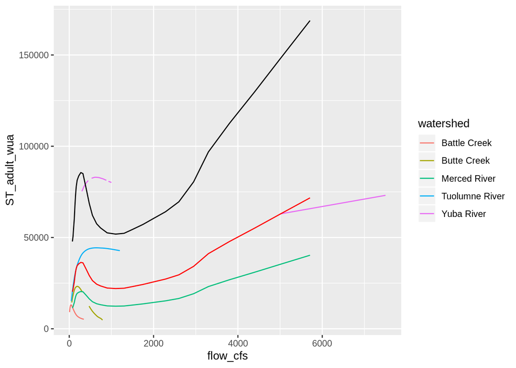

## Method

For unmodeled watersheds, we will take the annual mean flow for the watershed and calculate the wua value using Merced’s modeled relationship. We will then scale the wua by the ratio of mean flow between the watershed and Merced.

Here is a plot of the ratios (the black verticle line is at 1)

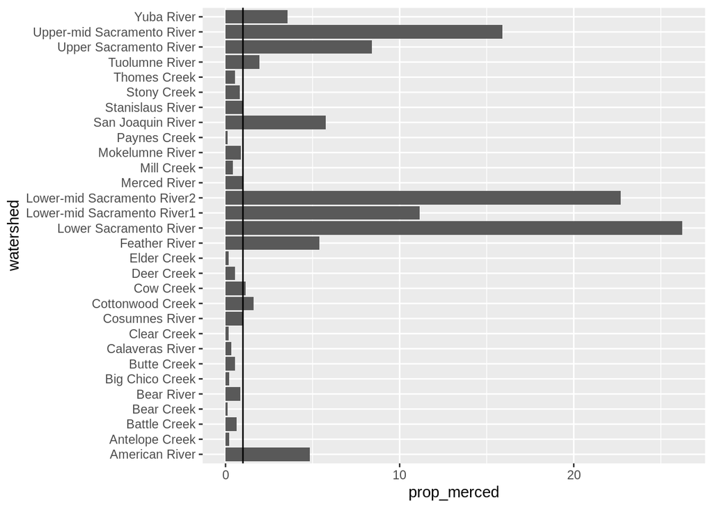